# Predicting the prices of Avacados

### About the data-

> The dataset represents weekly 2018 retail scan data for National retail volume (units) and price. Retail scan data comes directly from retailers’ cash registers based on actual retail sales of Hass avocados. Starting in 2013, the table below reflects an expanded, multi-outlet retail data set. Multi-outlet reporting includes an aggregation of the following channels: grocery, mass, club, drug, dollar and military. The Average Price (of avocados) in the table reflects a per unit (per avocado) cost, even when multiple units (avocados) are sold in bags. The Product Lookup codes (PLU’s) in the table are only for Hass avocados. Other varieties of avocados (e.g. greenskins) are not included in this table.

Some relevant columns in the dataset:

- Date - The date of the observation
- AveragePrice - the average price of a single avocado
- type - conventional or organic
- year - the year
- Region - the city or region of the observation
- Total Volume - Total number of avocados sold
- 4046 - Total number of avocados with PLU 4046 sold
- 4225 - Total number of avocados with PLU 4225 sold
- 4770 - Total number of avocados with PLU 4770 sold

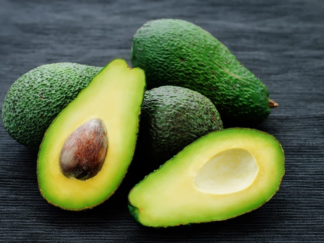

```python
#display image using python
#display image using python
from IPython.display import Image
url = 'https://img.etimg.com/thumb/msid-71806721,width-650,imgsize-807917,,resizemode-4,quality-100/avocados.jpg'
Image(url,height=300,width=400)
```

```python
#importing libraries
import numpy as np
import pandas as pd
import matplotlib.pyplot as plt
import seaborn as sns
sns.set()
import warnings
warnings.filterwarnings('ignore')
#importing the dataset
data = pd.read_csv(r'c:\Users\Hanshu\Desktop\excel data_ML\avocado.csv',index_col=0)
# Check the data
data.info()
```

```
<class 'pandas.core.frame.DataFrame'>
Index: 18249 entries, 0 to 11
Data columns (total 13 columns):
 #   Column        Non-Null Count  Dtype
---  ------        --------------  -----
 0   Date          18249 non-null  object
 1   AveragePrice  18249 non-null  float64
 2   Total Volume  18249 non-null  float64
 3   4046          18249 non-null  float64
 4   4225          18249 non-null  float64
 5   4770          18249 non-null  float64
 6   Total Bags    18249 non-null  float64
 7   Small Bags    18249 non-null  float64
 8   Large Bags    18249 non-null  float64
 9   XLarge Bags   18249 non-null  float64
 10  type          18249 non-null  object
 11  year          18249 non-null  int64
 12  region        18249 non-null  object
dtypes: float64(9), int64(1), object(3)
memory usage: 1.9+ MB
```

There are 3 categorical features and luckily no missing value. Let's explore the data further.

```python
data.head(3)
```

|  | Date | AveragePrice | Total Volume | 4046 | 4225 | 4770 | Total Bags | Small Bags | Large Bags | XLarge Bags | type | year | region |
| --- | --- | --- | --- | --- | --- | --- | --- | --- | --- | --- | --- | --- | --- |
| 0 | 2015-12-27 | 1.33 | 64236.62 | 1036.74 | 54454.85 | 48.16 | 8696.87 | 8603.62 | 93.25 | 0.0 | conventional | 2015 | Albany |
| 1 | 2015-12-20 | 1.35 | 54876.98 | 674.28 | 44638.81 | 58.33 | 9505.56 | 9408.07 | 97.49 | 0.0 | conventional | 2015 | Albany |
| 2 | 2015-12-13 | 0.93 | 118220.22 | 794.70 | 109149.67 | 130.50 | 8145.35 | 8042.21 | 103.14 | 0.0 | conventional | 2015 | Albany |

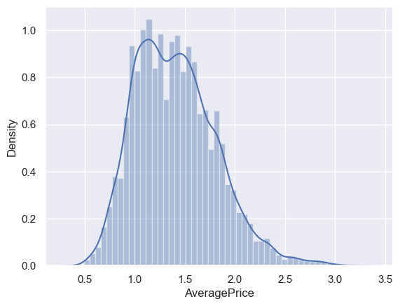

```python
sns.distplot(data['AveragePrice']);
```

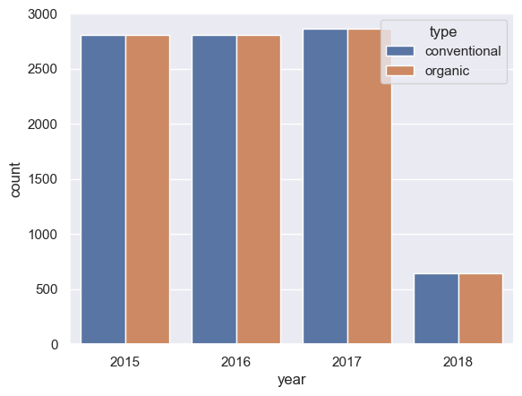

```python
sns.countplot(x='year', data=data,hue='type');
```

There are almost equal numbers of conventional and organic avacados. Though, there is very less observations in the year 2018.

```python
data.year.value_counts()
```

```
year
2017    5722
2016    5616
2015    5615
2018    1296
Name: count, dtype: int64
```

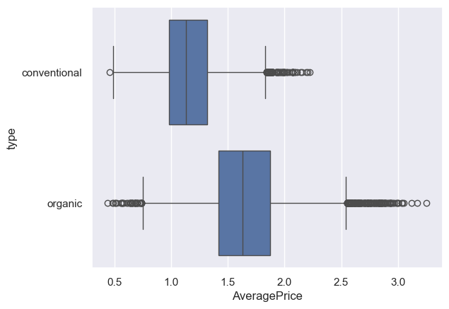

```python
sns.boxplot(y='type', x='AveragePrice', data=data);
```

Organic avocados are more expensive. This is obvious, because their cultivation is more expensive and we all love natural products and are willing to pay a higher price for them.

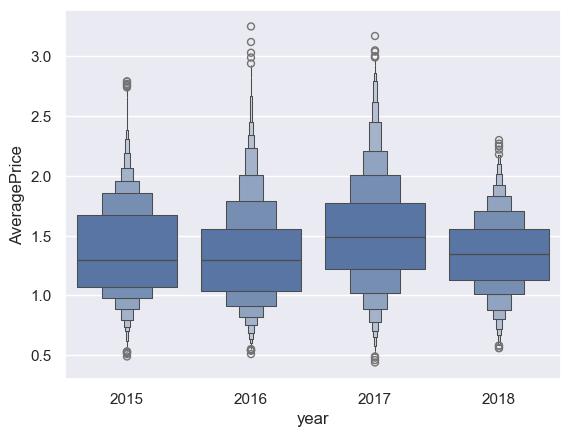

```python
data.year=data.year.apply(str)
sns.boxenplot(x='year', y='AveragePrice', data=data)
```

Avacados were slightly more expensive in the year 2017.(as there was shortage due to some reasons)

### Dealing with categorical features.

```python
print(data.columns)
```

```
Index(['Date', 'AveragePrice', 'Total Volume', '4046', '4225', '4770',
       'Total Bags', 'Small Bags', 'Large Bags', 'XLarge Bags', 'type', 'year',
       'region'],
      dtype='object')
```

```python
data['type']= data['type'].map({'conventional':0,'organic':1})

# Extracting month from date column.
data['Date'] = pd.to_datetime(data['Date'])
data['Month']=data['Date'].apply(lambda x:x.month)
data.drop('Date',axis=1,inplace=True)
data.Month = data.Month.map({1:'JAN',2:'FEB',3:'MARCH',4:'APRIL',5:'MAY',6:'JUNE',7:'JULY',8:'AUG',9:'SEPT',10:'OCT',11:'NOV',12:'DEC'})
```

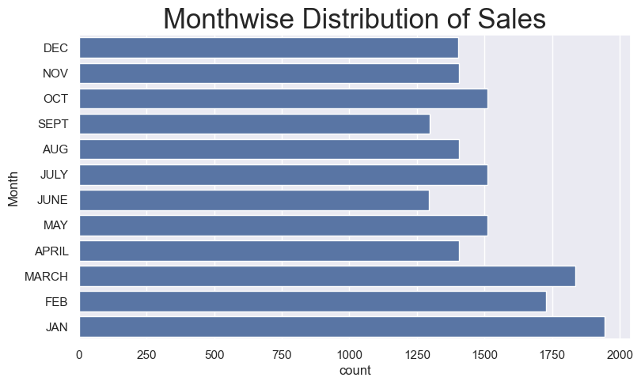

```python
plt.figure(figsize=(9,5))
sns.countplot(data['Month'])
plt.title('Monthwise Distribution of Sales',fontdict={'fontsize':25});
```

It implies that sales of avacado see a rise in January, Febuary and March.

## Preparing data for ML models

```python
# Creating dummy variables
dummies = pd.get_dummies(data[['year','region','Month']],drop_first=True)
df_dummies = pd.concat([data[['Total Volume', '4046', '4225', '4770', 'Total Bags',
       'Small Bags', 'Large Bags', 'XLarge Bags', 'type']],dummies],axis=1)
target = data['AveragePrice']

# Splitting data into training and test set
from sklearn.model_selection import train_test_split
X_train, X_test, y_train, y_test = train_test_split(df_dummies,target,test_size=0.30)

# Standardizing the data
cols_to_std = ['Total Volume', '4046', '4225', '4770', 'Total Bags', 'Small Bags','Large Bags', 'XLarge Bags']
from sklearn.preprocessing import StandardScaler
scaler=StandardScaler()
scaler.fit(X_train[cols_to_std])
X_train[cols_to_std] = scaler.transform(X_train[cols_to_std])
X_test[cols_to_std] = scaler.transform(X_test[cols_to_std])
```

```python
#importing ML models from scikit-learn
from sklearn.linear_model import LinearRegression
from sklearn.tree import DecisionTreeRegressor
from sklearn.ensemble import RandomForestRegressor
from sklearn.svm import SVR
from sklearn.neighbors import KNeighborsRegressor
from xgboost import XGBRegressor
from sklearn.metrics import mean_absolute_error,mean_squared_error,r2_score
```

```python
#to save time all models can be applied once using for loop
regressors = {
    'Linear Regression' : LinearRegression(),
    'Decision Tree' : DecisionTreeRegressor(),
    'Random Forest' : RandomForestRegressor(),
    'Support Vector Machines' : SVR(gamma=1),
    'K-nearest Neighbors' : KNeighborsRegressor(n_neighbors=1),
    'XGBoost' : XGBRegressor()
}
results=pd.DataFrame(columns=['MAE','MSE','R2-score'])
for method,func in regressors.items():
    model = func.fit(X_train,y_train)
    pred = model.predict(X_test)
    results.loc[method]= [np.round(mean_absolute_error(y_test,pred),3),
                          np.round(mean_squared_error(y_test,pred),3),
                          np.round(r2_score(y_test,pred),3)
                         ]
```

## Deep Neural Network

```python
%pip install tensorflow

# Splitting train set into training and validation sets.
X_train, X_val, y_train, y_val = train_test_split(X_train,y_train,test_size=0.20)

#importing tensorflow libraries
import tensorflow as tf
from tensorflow.keras.models import Sequential
from tensorflow.keras.layers import Dense, Activation,Dropout
from tensorflow.keras.optimizers import Adam
from tensorflow.keras.callbacks import EarlyStopping

#creating model
model = Sequential()
model.add(Dense(76,activation='relu',kernel_initializer=tf.random_uniform_initializer(minval=-0.1, maxval=0.1),
    bias_initializer=tf.random_uniform_initializer(minval=-0.1, maxval=0.1)))
model.add(Dense(200,activation='relu',kernel_initializer=tf.random_uniform_initializer(minval=-0.1, maxval=0.1),
    bias_initializer=tf.random_uniform_initializer(minval=-0.1, maxval=0.1)))
model.add(Dropout(0.5))
model.add(Dense(200,activation='relu',kernel_initializer=tf.random_uniform_initializer(minval=-0.1, maxval=0.1),
    bias_initializer=tf.random_uniform_initializer(minval=-0.1, maxval=0.1)))
model.add(Dropout(0.5))
model.add(Dense(200,activation='relu',kernel_initializer=tf.random_uniform_initializer(minval=-0.1, maxval=0.1),
    bias_initializer=tf.random_uniform_initializer(minval=-0.1, maxval=0.1)))
model.add(Dropout(0.5))
model.add(Dense(1))

model.compile(optimizer='Adam', loss='mean_squared_error')
early_stop = EarlyStopping(monitor='val_loss', mode='min', verbose=0, patience=10)
```

[output not shown]

[output cut: 4829 more lines]

[output not shown]

[output not shown]

```python
# Convert boolean columns to int and ensure all columns are numeric
X_train_numeric = X_train.copy()
X_val_numeric = X_val.copy()
for df in [X_train_numeric, X_val_numeric]:
    for col in df.select_dtypes(include='bool').columns:
        df[col] = df[col].astype(int)
    for col in df.select_dtypes(include='object').columns:
        df[col] = df[col].astype(float)

model.fit(x=X_train_numeric.values, y=y_train.values,
          validation_data=(X_val_numeric.values, y_val.values),
          batch_size=100, epochs=150, callbacks=[early_stop])
```

```
82/82 ━━━━━━━━━━━━━━━━━━━━ 3s 8ms/step - loss: 0.3327 - val_loss: 0.1145
82/82 ━━━━━━━━━━━━━━━━━━━━ 0s 5ms/step - loss: 0.1191 - val_loss: 0.0776
82/82 ━━━━━━━━━━━━━━━━━━━━ 0s 5ms/step - loss: 0.1001 - val_loss: 0.0600
82/82 ━━━━━━━━━━━━━━━━━━━━ 0s 5ms/step - loss: 0.0894 - val_loss: 0.0613
82/82 ━━━━━━━━━━━━━━━━━━━━ 0s 5ms/step - loss: 0.0794 - val_loss: 0.0626
82/82 ━━━━━━━━━━━━━━━━━━━━ 0s 5ms/step - loss: 0.0742 - val_loss: 0.0436
82/82 ━━━━━━━━━━━━━━━━━━━━ 0s 5ms/step - loss: 0.0688 - val_loss: 0.0378
82/82 ━━━━━━━━━━━━━━━━━━━━ 0s 5ms/step - loss: 0.0623 - val_loss: 0.0413
82/82 ━━━━━━━━━━━━━━━━━━━━ 1s 7ms/step - loss: 0.0610 - val_loss: 0.0421
82/82 ━━━━━━━━━━━━━━━━━━━━ 0s 5ms/step - loss: 0.0581 - val_loss: 0.0369
82/82 ━━━━━━━━━━━━━━━━━━━━ 0s 5ms/step - loss: 0.0560 - val_loss: 0.0353
82/82 ━━━━━━━━━━━━━━━━━━━━ 0s 6ms/step - loss: 0.0535 - val_loss: 0.0341
82/82 ━━━━━━━━━━━━━━━━━━━━ 0s 5ms/step - loss: 0.0517 - val_loss: 0.0349
82/82 ━━━━━━━━━━━━━━━━━━━━ 1s 6ms/step - loss: 0.0506 - val_loss: 0.0320
82/82 ━━━━━━━━━━━━━━━━━━━━ 0s 5ms/step - loss: 0.0477 - val_loss: 0.0319
82/82 ━━━━━━━━━━━━━━━━━━━━ 0s 5ms/step - loss: 0.0485 - val_loss: 0.0308
82/82 ━━━━━━━━━━━━━━━━━━━━ 1s 6ms/step - loss: 0.0455 - val_loss: 0.0318
82/82 ━━━━━━━━━━━━━━━━━━━━ 0s 5ms/step - loss: 0.0460 - val_loss: 0.0298
82/82 ━━━━━━━━━━━━━━━━━━━━ 0s 5ms/step - loss: 0.0433 - val_loss: 0.0305
82/82 ━━━━━━━━━━━━━━━━━━━━ 0s 6ms/step - loss: 0.0428 - val_loss: 0.0310
82/82 ━━━━━━━━━━━━━━━━━━━━ 0s 5ms/step - loss: 0.0417 - val_loss: 0.0293
82/82 ━━━━━━━━━━━━━━━━━━━━ 0s 5ms/step - loss: 0.0414 - val_loss: 0.0292
82/82 ━━━━━━━━━━━━━━━━━━━━ 0s 5ms/step - loss: 0.0401 - val_loss: 0.0280
82/82 ━━━━━━━━━━━━━━━━━━━━ 0s 5ms/step - loss: 0.0384 - val_loss: 0.0279
82/82 ━━━━━━━━━━━━━━━━━━━━ 1s 6ms/step - loss: 0.0380 - val_loss: 0.0269
82/82 ━━━━━━━━━━━━━━━━━━━━ 0s 5ms/step - loss: 0.0374 - val_loss: 0.0272
82/82 ━━━━━━━━━━━━━━━━━━━━ 0s 5ms/step - loss: 0.0361 - val_loss: 0.0279
82/82 ━━━━━━━━━━━━━━━━━━━━ 0s 5ms/step - loss: 0.0356 - val_loss: 0.0294
82/82 ━━━━━━━━━━━━━━━━━━━━ 1s 6ms/step - loss: 0.0351 - val_loss: 0.0267
82/82 ━━━━━━━━━━━━━━━━━━━━ 0s 5ms/step - loss: 0.0340 - val_loss: 0.0261
82/82 ━━━━━━━━━━━━━━━━━━━━ 0s 5ms/step - loss: 0.0335 - val_loss: 0.0259
82/82 ━━━━━━━━━━━━━━━━━━━━ 0s 5ms/step - loss: 0.0337 - val_loss: 0.0297
82/82 ━━━━━━━━━━━━━━━━━━━━ 0s 5ms/step - loss: 0.0327 - val_loss: 0.0298
82/82 ━━━━━━━━━━━━━━━━━━━━ 0s 5ms/step - loss: 0.0326 - val_loss: 0.0269
82/82 ━━━━━━━━━━━━━━━━━━━━ 1s 6ms/step - loss: 0.0315 - val_loss: 0.0256
82/82 ━━━━━━━━━━━━━━━━━━━━ 0s 5ms/step - loss: 0.0307 - val_loss: 0.0264
82/82 ━━━━━━━━━━━━━━━━━━━━ 0s 5ms/step - loss: 0.0292 - val_loss: 0.0260
82/82 ━━━━━━━━━━━━━━━━━━━━ 0s 5ms/step - loss: 0.0292 - val_loss: 0.0269
82/82 ━━━━━━━━━━━━━━━━━━━━ 0s 6ms/step - loss: 0.0301 - val_loss: 0.0253
82/82 ━━━━━━━━━━━━━━━━━━━━ 1s 7ms/step - loss: 0.0277 - val_loss: 0.0245
82/82 ━━━━━━━━━━━━━━━━━━━━ 1s 6ms/step - loss: 0.0277 - val_loss: 0.0258
82/82 ━━━━━━━━━━━━━━━━━━━━ 1s 6ms/step - loss: 0.0285 - val_loss: 0.0259
82/82 ━━━━━━━━━━━━━━━━━━━━ 1s 7ms/step - loss: 0.0274 - val_loss: 0.0255
82/82 ━━━━━━━━━━━━━━━━━━━━ 1s 6ms/step - loss: 0.0266 - val_loss: 0.0263
82/82 ━━━━━━━━━━━━━━━━━━━━ 0s 5ms/step - loss: 0.0262 - val_loss: 0.0258
82/82 ━━━━━━━━━━━━━━━━━━━━ 1s 6ms/step - loss: 0.0254 - val_loss: 0.0250
82/82 ━━━━━━━━━━━━━━━━━━━━ 0s 5ms/step - loss: 0.0258 - val_loss: 0.0258
82/82 ━━━━━━━━━━━━━━━━━━━━ 0s 6ms/step - loss: 0.0255 - val_loss: 0.0256
82/82 ━━━━━━━━━━━━━━━━━━━━ 1s 7ms/step - loss: 0.0242 - val_loss: 0.0244
82/82 ━━━━━━━━━━━━━━━━━━━━ 1s 7ms/step - loss: 0.0243 - val_loss: 0.0240
82/82 ━━━━━━━━━━━━━━━━━━━━ 1s 6ms/step - loss: 0.0233 - val_loss: 0.0243
82/82 ━━━━━━━━━━━━━━━━━━━━ 0s 5ms/step - loss: 0.0229 - val_loss: 0.0264
82/82 ━━━━━━━━━━━━━━━━━━━━ 0s 5ms/step - loss: 0.0234 - val_loss: 0.0246
82/82 ━━━━━━━━━━━━━━━━━━━━ 0s 5ms/step - loss: 0.0226 - val_loss: 0.0246
82/82 ━━━━━━━━━━━━━━━━━━━━ 1s 6ms/step - loss: 0.0218 - val_loss: 0.0241
82/82 ━━━━━━━━━━━━━━━━━━━━ 0s 6ms/step - loss: 0.0223 - val_loss: 0.0241
82/82 ━━━━━━━━━━━━━━━━━━━━ 1s 6ms/step - loss: 0.0212 - val_loss: 0.0254
82/82 ━━━━━━━━━━━━━━━━━━━━ 0s 5ms/step - loss: 0.0218 - val_loss: 0.0243
82/82 ━━━━━━━━━━━━━━━━━━━━ 1s 6ms/step - loss: 0.0210 - val_loss: 0.0243
82/82 ━━━━━━━━━━━━━━━━━━━━ 0s 5ms/step - loss: 0.0216 - val_loss: 0.0252
```

```
<keras.src.callbacks.history.History at 0x294fe52c110>
```

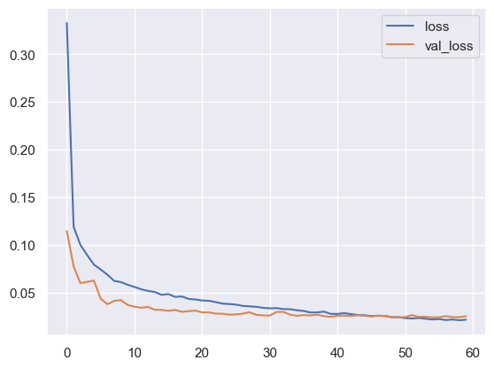

```python
losses = pd.DataFrame(model.history.history)
losses[['loss','val_loss']].plot();
```

```python
dnn_pred = model.predict(X_test)
```

```
172/172 ━━━━━━━━━━━━━━━━━━━━ 0s 2ms/step
```

## Results table

```python
results.loc['Deep Neural Network']=[round(mean_absolute_error(y_test,dnn_pred),3), round(mean_squared_error(y_test,dnn_pred),3),
                                    round(r2_score(y_test,dnn_pred),3)]
results
```

|  | MAE | MSE | R2-score |
| --- | --- | --- | --- |
| Linear Regression | 0.183 | 0.059 | 0.639 |
| Decision Tree | 0.143 | 0.047 | 0.713 |
| Random Forest | 0.103 | 0.022 | 0.868 |
| Support Vector Machines | 0.126 | 0.032 | 0.805 |
| K-nearest Neighbors | 0.112 | 0.030 | 0.814 |
| XGBoost | 0.097 | 0.018 | 0.890 |
| Deep Neural Network | 0.116 | 0.027 | 0.836 |

```python
f"10% of mean of target variable is {np.round(0.1 * data.AveragePrice.mean(),3)}"
```

```
'10% of mean of target variable is 0.141'
```

Let's have a look at methods performing best as they have R2-score close to 1.

```python
results.sort_values('R2-score',ascending=False).style.background_gradient(cmap='Greens',subset=['R2-score'])
```

[output not shown]